# Introduction to `SpatialData`

Helena L. Crowell, Louise Deconinck, Artür Manukyan, Dario Righelli, Estella Dong, Samuel Gunz, Yixing E. Dong, Michael Stadler, Charlotte Soneson, Vince Carey and Hugo Gruson

April 29, 2026

#### Package

SpatialData 0.99.31

# 1 Introduction

The *SpatialData* package provides an R interface to the [SpatialData](https://spatialdata.scverse.org) framework, a unified ecosystem for handling spatial omics data. Developed as part of the [scverse](https://scverse.org) project (Virshup et al. 2023), `SpatialData` aims to solve the challenges of integrating diverse spatial datasets—including imaging, spatial transcriptomics, and proteomics—by employing the [OME-NGFF (Next Generation File Format)](https://ngff.openmicroscopy.org) standard (Marconato et al. 2024).

The Python implementation and core specifications can be found at the [official SpatialData website](https://spatialdata.scverse.org).

## 1.1 Data Representation in R

The core of the package is the `SpatialData` class, which serves as a container for multiple layers of spatial information:

- **Images**: Multiscale, multi-channel raster data, represented as `ZarrArray` objects via the *Rarr* and *ZarrArray* packages.
- **Labels**: Segmentation masks (e.g., cell or nuclei boundaries), also stored as `ZarrArray`s.
- **Points**: High-resolution coordinates (e.g., individual transcript molecules), handled as *arrow* tables or *duckdb*-backed data frames for efficient out-of-memory processing.
- **Shapes**: Polygonal regions of interest or circular markers, represented similarly to points but with geometric metadata.
- **Tables**: Functional annotations (e.g., gene expression counts), stored as *SingleCellExperiment* objects.

# 2 Getting Started

First, we load the necessary libraries:

```r
library(SpatialData)
library(SingleCellExperiment)
```

## 2.1 Reading Data

`SpatialData` objects are typically read from `.zarr` stores. The package provides the `readSpatialData()` function to ingest an entire store.

```r
# Path to a toy dataset included in the package
path <- system.file("extdata", "blobs.zarr", package="SpatialData")

# Read the complete SpatialData object
sd <- readSpatialData(path)
sd
```

```
## class: SpatialData
## - images(2):
##   - blobs_image (3,64,64)
##   - blobs_multiscale_image (3,64,64)
## - labels(2):
##   - blobs_labels (64,64)
##   - blobs_multiscale_labels (64,64)
## - points(1):
##   - blobs_points (200)
## - shapes(3):
##   - blobs_circles (5,circle)
##   - blobs_multipolygons (2,polygon)
##   - blobs_polygons (5,polygon)
## - tables(1):
##   - table (3,10) [blobs_labels]
## coordinate systems(5):
## - global(8): blobs_image blobs_multiscale_image ... blobs_polygons
##   blobs_points
## - scale(1): blobs_labels
## - translation(1): blobs_labels
## - affine(1): blobs_labels
## - sequence(1): blobs_labels
```

## 2.2 AnnData Integration with `anndataR`

For spatial omics datasets, functional annotations are often stored as [AnnData](https://anndata.readthedocs.io) objects in Python. The *anndataR* package (Deconinck et al. 2025) is used by `SpatialData` to seamlessly read these `.zarr`-backed `AnnData` objects into R as `SingleCellExperiment` objects.

By default, `readSpatialData(..., anndataR=TRUE)` will use this package to ingest any tables found in the Zarr store.

# 3 Coordinate Systems and Transformations

A key feature of the `SpatialData` framework is its robust handling of coordinate systems. Each element can exist in multiple coordinate spaces simultaneously, defined by transformations in its metadata.

## 3.1 Coordinate Transformation Graph

The relationships between different elements and their respective coordinate spaces can be complex. `SpatialData` provides the `CTgraph()` function to visualize these relationships as a directed graph.

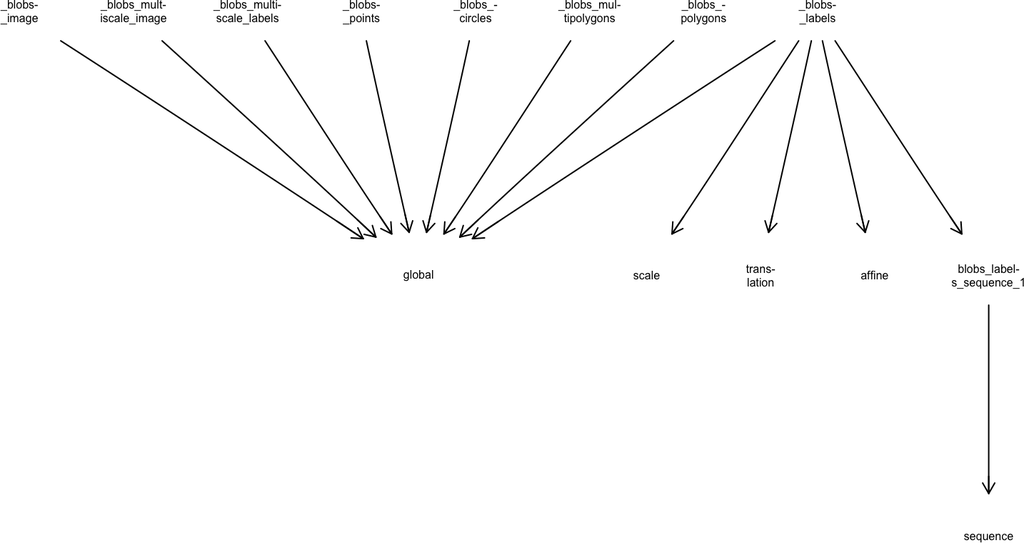

Figure 1: Coordinate transformation graph for the ‘blobs’ dataset

```r
if (requireNamespace("Rgraphviz", quietly = TRUE)) {
    g <- CTgraph(sd)
    CTplot(g)
}
```

In this graph:

- **source nodes** (prefixed with `_`) represent the individual data layers (images, labels, etc.).
- **target nodes** represent the coordinate systems (e.g., `global`, `sequence`).
- **edges** represent the transformations (scale, translation, etc.) required to map an element into a specific space.

## 3.2 Applying Transformations

The `transform()` function resolves the necessary steps to project an element into a target coordinate system by traversing this graph:

```r
# Retrieve a point element
p <- point(sd, 1)

# Project it into the 'global' coordinate space
q <- SpatialData::transform(p, "global")
```

# 4 Spatial Queries

`SpatialData` supports sophisticated spatial operations such as cropping, which are propagated across all layers:

```r
# Define a bounding box for cropping
bb <- list(xmin=10, xmax=50, ymin=10, ymax=50)

# Crop the entire object
(sp <- crop(sd, bb, j="global"))
```

```
## class: SpatialData
## - images(2):
##   - blobs_image (3,40,40)
##   - blobs_multiscale_image (3,40,40)
## - labels(2):
##   - blobs_labels (40,40)
##   - blobs_multiscale_labels (40,40)
## - points(1):
##   - blobs_points (92)
## - shapes(3):
##   - blobs_circles (5,circle)
##   - blobs_multipolygons (2,polygon)
##   - blobs_polygons (5,polygon)
## - tables(1):
##   - table (3,10) [blobs_labels]
## coordinate systems(5):
## - global(8): blobs_image blobs_multiscale_image ... blobs_polygons
##   blobs_points
## - scale(1): blobs_labels
## - translation(1): blobs_labels
## - affine(1): blobs_labels
## - sequence(1): blobs_labels
```

# 5 Integration with Tables

Tables (SCE objects) link to specific labels or shapes using `region` and `instance_key` identifiers, allowing for seamless integration of spatial and feature-level information.

```r
(sce <- SpatialData::table(sd))
```

```
## class: SingleCellExperiment
## dim: 3 10
## metadata(0):
## assays(1): X
## rownames(3): channel_0_sum channel_1_sum channel_2_sum
## rowData names(0):
## colnames(10): 3 4 ... 15 16
## colData names(0):
## reducedDimNames(0):
## mainExpName: NULL
## altExpNames(0):
```

```r
# Check which region this table annotates
region(sce)
```

```
## [1] "blobs_labels"
```

```r
# Check which instances are being annotated
instances(sce)
```

```
##  [1]  3  4  5  8 10 11 12 13 15 16
```

# 6 Conclusion

The `SpatialData` package brings the power of the scverse spatial ecosystem to R, providing a scalable and interoperable foundation for spatial omics analysis. By adhering to the OME-NGFF standard and integrating with established Bioconductor objects, it enables seamless cross-platform workflows.

# References

Deconinck, Louise, Luke Zappia, Robrecht Cannoodt, et al. 2025. “anndataR improves interoperability between R and Python in single-cell transcriptomics.” *bioRxiv*, 2025.08.18.669052. https://doi.org/10.1101/2025.08.18.669052.

Marconato, Luca, Giovanni Palla, Kevin A Yamauchi, et al. 2024. “SpatialData: an open and universal data framework for spatial omics.” *Nature Methods*, ahead of print. https://doi.org/10.1038/s41592-024-02212-x.

Virshup, Isaac, Danila Bredikhin, Lukas Heumos, et al. 2023. “The scverse project provides a computational ecosystem for single-cell omics data analysis.” *Nature Biotechnology* 41 (5): 604–6. https://doi.org/10.1038/s41587-023-01733-8.